# Supplement to PS 9 Solutions

Michael Chirico

Compiled November 14, 2016 at 14:51

# Problem 1

## (d)

```r
library(data.table)

thermo = fread("q1data.csv")
#Preview data
thermo
```

```
##       V1     x
##   1:   1 51.13
##   2:   2 44.37
##   3:   3 44.20
##   4:   4 26.33
##   5:   5 65.74
##  ---
## 496: 496 42.25
## 497: 497 58.22
## 498: 498 39.17
## 499: 499 60.20
## 500: 500 67.09
```

```r
#find mean & standard deviation
thermo[ , .(mean = mean(x), st.dev = sd(x))]
```

```
##        mean   st.dev
## 1: 55.06984 12.37634
```

## (e)

R makes it really easy to calculate both more-exact t-distributed confidence intervals and the approximate intervals generated from the corresponding normal distribution:

```r
#Exact CI, 90%
thermo[ , .(lower = mean(x) - qt(.95, df = .N - 1L)*sd(x)/sqrt(.N),
            upper = mean(x) + qt(.95, df = .N - 1L)*sd(x)/sqrt(.N))]
```

```
##       lower    upper
## 1: 54.15774 55.98194
```

```r
#Approximate CI, 90% (ever-so-slightly narrower)
thermo[ , .(lower = mean(x) - qnorm(.95)*sd(x)/sqrt(.N),
            upper = mean(x) + qnorm(.95)*sd(x)/sqrt(.N))]
```

```
##       lower    upper
## 1: 54.15944 55.98024
```

```r
#Now for 95%
thermo[ , .(lower = mean(x) - qt(.975, df = .N - 1L)*sd(x)/sqrt(.N),
            upper = mean(x) + qt(.975, df = .N - 1L)*sd(x)/sqrt(.N))]
```

```
##       lower    upper
## 1: 53.98239 56.15729
```

```r
thermo[ , .(lower = mean(x) - qnorm(.975)*sd(x)/sqrt(.N),
            upper = mean(x) + qnorm(.975)*sd(x)/sqrt(.N))]
```

```
##       lower    upper
## 1: 53.98503 56.15465
```

```r
#Now for 99%
thermo[ , .(lower = mean(x) - qt(.995, df = .N - 1L)*sd(x)/sqrt(.N),
            upper = mean(x) + qt(.995, df = .N - 1L)*sd(x)/sqrt(.N))]
```

```
##       lower  upper
## 1: 53.63868 56.501
```

```r
thermo[ , .(lower = mean(x) - qnorm(.995)*sd(x)/sqrt(.N),
            upper = mean(x) + qnorm(.995)*sd(x)/sqrt(.N))]
```

```
##       lower    upper
## 1: 53.64415 56.49553
```

We could also use the handy `t.test` function to do this for us all at once. We use `t.test` to test the hypothesis that the mean of `x` is the sample mean of `x`; as a byproduct, it gives us the appropriate confidence intervals. Note that this approach uses the t-distributed critical values by default. `t.test` can also handle an alpha level of 1 for 100% confidence intervals.

```r
sapply(c(.9, .95, .99, 1), function(conf)
  thermo[ , t.test(x, mu = mean(x), conf.level = conf)$conf.int])
```

```
##          [,1]     [,2]     [,3] [,4]
## [1,] 54.15774 53.98239 53.63868 -Inf
## [2,] 55.98194 56.15729 56.50100  Inf
```

## (f)

```r
sapply(c(.9, .95, .99), function(conf)
  thermo[ , mean(x) + c(-1, 1)*qnorm((conf+1)/2) * 12/sqrt(.N)])
```

```
##          [,1]     [,2]     [,3]
## [1,] 54.18712 54.01801 53.68750
## [2,] 55.95256 56.12167 56.45218
```

# 2

# (e) Bonus Q

We know that the coverage probability for a given $a$ and $b$ is

$$p(a, b) = \frac1{a^n} - \frac1{b^n}$$

Recalling the goal of efficiency is to have as small an interval as possible in mind, and remembering that $\hat{\theta}_n$ is itself biased, it makes sense to wonder how to choose $a$ and $b$ so as to minimize the interval width. It’s not immediately obvious that $a^{*}$ should be 1 – it could *ex ante* be anything between $1$ and $\frac{n+1}{n}$ (the bias adjustment constant found in PS6).

To narrow it down – we must state the precise problem we have in mind, namely:

$$\min_{a, b} \left\{ b - a \right\}$$

subject to $1 \leq a < b$ and $\frac1{a^n} - \frac1{b^n} = p$ – in words, we minimize the distance between $b$ and $a$ given that they give the desired coverage probability.

Noting lots of exponentiation afoot, it makes sense to consider an equivalent version of the problem, namely:

$$\min_{\alpha, \beta} \left\{ \beta - \alpha \right\}$$

subject to $0 \leq \alpha < \beta$ and $e^{-n\alpha} - e^{-n\beta} = p$ (we’ve simply replaced $a$ by $e^\alpha$ and $b$ by $e^\beta$).

Solving the coverage constraint for $\beta$ in terms of $\alpha$ we get

$$\beta(\alpha) = -\frac1{n} \ln \left( e^{-n\alpha} - p \right)$$

Note that the domain of $\beta(\alpha)$ is $[0, -\frac1{n} \ln p)$. In order for the first-order condition of our minimization problem to hold, we must have $\frac{\partial \beta}{\partial \alpha} = 1$ for some $\alpha$ in that domain.

But $\frac{\partial \beta}{\partial \alpha} = \frac1{1 - pe^{n \alpha}} \geq \frac1{1 - p}$ for $\alpha$ in this range.

That means $\beta(\alpha) - \alpha$ is strictly increasing in $\alpha$, so the optimal $\alpha$ is indeed 0.

That means $a^{*} = 1$ and $b^{*} = \frac1{\sqrt[n]{1 - p}}$, the latter of which approaches 1 as $n$ increases. Thus (recalling that this specification is fully flexible given that $\theta_0 \geq \hat{\theta}_n$) the optimal confidence interval takes the form:

$$\left[ \hat{\theta}_n, \frac1{\sqrt[n]{1 - p}} \hat{\theta}_n \right]$$

Recall that the unbiased estimate for $\theta_0$ is $\frac{n+1}{n} \hat{\theta}_n$. Unlike for the symmetric confidince interval, there’s no guarantee that this optimal interval contains this unbiased estimate for all $p$! This is easy to see if we set $p = 0$, in which case the interval collapses to the single point $\hat{\theta}_n$.

For $\frac{n+1}{n} \hat{\theta}_n$ to be in the interval above, we must have $\frac1{\sqrt[n]{1-p}} \geq \frac{n+1}{n}$, which is in turn equivalent to $p \geq 1 - \left( 1 + \frac1{n} \right)^{-n}$; for $n = 1$, this is $p \geq \frac12$, and as $n \rightarrow \infty$, this increases to the limiting value $p \geq 1 - \frac1{e} \approx .63$.

(So in fact, for any reasonable $n$ and any common $p$ such as $.9$ or $.95$, the interval does in fact contain the unbiased estimate)

# 3

## (a)

Can do this with R (a bit overkill); note that `t.test` gives all all the output we could want – the $t$ statistic, the $p$-value, and the 95% confidence interval (and we could specify `conf.level` if we wanted a different coverage probability):

```r
ben = c(6.1, 3.7, 4.2, 5.2, 5.8)
t.test(ben, alternative = "greater", mu = 4)
```

```
##
##  One Sample t-test
##
## data:  ben
## t = 2.177, df = 4, p-value = 0.04753
## alternative hypothesis: true mean is greater than 4
## 95 percent confidence interval:
##  4.020742      Inf
## sample estimates:
## mean of x
##         5
```

## (b) & (c)

We’ll use `t.test` again. `t.test` will also answer part (c) for us.

```r
ben = fread("ben_races.csv")
#preview data
head(ben)
```

```
##     our_ben bronze_ben ben_on_the_bench
## 1: 4.604218   6.610315         4.080604
## 2: 5.794743   5.892869         5.115813
## 3: 5.099114   4.748795         8.177618
## 4: 4.828914   5.225726         5.059685
## 5: 5.735272   5.893074         5.763614
## 6: 5.310251   4.065083         4.849784
```

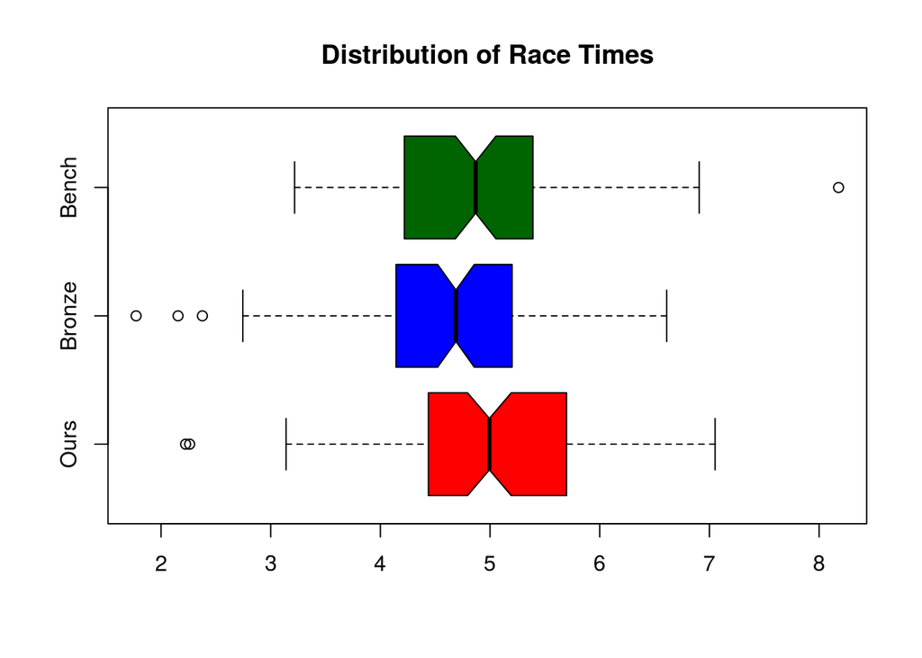

```r
boxplot(ben, horizontal = TRUE,
        names = c("Ours", "Bronze", "Bench"),
        main = "Distribution of Race Times",
        col = c("red", "blue", "darkgreen"),
        #the notch gives a confidence interval
        #  around the sample median
        notch = TRUE)
```

```r
# (i)
ben[ , t.test(ben_on_the_bench, bronze_ben)]
```

```
##
##  Welch Two Sample t-test
##
## data:  ben_on_the_bench and bronze_ben
## t = 1.7971, df = 196.35, p-value = 0.07386
## alternative hypothesis: true difference in means is not equal to 0
## 95 percent confidence interval:
##  -0.02319993  0.49956673
## sample estimates:
## mean of x mean of y
##  4.896861  4.658678
```

```r
# (ii)
ben[ , t.test(bronze_ben, our_ben)]
```

```
##
##  Welch Two Sample t-test
##
## data:  bronze_ben and our_ben
## t = -2.5238, df = 198, p-value = 0.0124
## alternative hypothesis: true difference in means is not equal to 0
## 95 percent confidence interval:
##  -0.62401072 -0.07658454
## sample estimates:
## mean of x mean of y
##  4.658678  5.008976
```

```r
# (iii) (also c) i))
ben[ , t.test(ben_on_the_bench, our_ben)]
```

```
##
##  Welch Two Sample t-test
##
## data:  ben_on_the_bench and our_ben
## t = -0.84374, df = 196.18, p-value = 0.3998
## alternative hypothesis: true difference in means is not equal to 0
## 95 percent confidence interval:
##  -0.3741668  0.1499384
## sample estimates:
## mean of x mean of y
##  4.896861  5.008976
```

## (d)

Though the $p$-values alone don’t tell us the answer, we *can* test this hypothesis:

```r
ben[ , t.test(our_ben - bronze_ben, our_ben - ben_on_the_bench)]
```

```
##
##  Welch Two Sample t-test
##
## data:  our_ben - bronze_ben and our_ben - ben_on_the_bench
## t = 1.1489, df = 196.55, p-value = 0.252
## alternative hypothesis: true difference in means is not equal to 0
## 95 percent confidence interval:
##  -0.1706735  0.6470403
## sample estimates:
## mean of x mean of y
## 0.3502976 0.1121142
```

So in fact we can’t say whether this mean is significantly different.